[output not shown]

# Survey Methodology

Camden County LMI Income Limits by Household Size

| Household Size | Threshold |
| --- | --- |
| 1 | $37,050 |
| 2 | $42,350 |
| 3 | $47,650 |
| 4 | $52,900 |
| 5 | $57,150 |
| 6 | $61,400 |
| 7 | $65,600 |
| 8+ | $69,850 |

## Step 1: Selecting the Survey Method

The survey method selected was mail survey using utility billing. All households in Kingsland, Georgia received a QR code in their utility bill that could be used to access the survey.

## Step 2: Developing a Questionnare

We developed the survey using input from stakeholders in Camden County, primarily Steven Sainz. The survey questions were embedded into a broader, anonymous ARPA needs assessment survey. Therefore, we did not collect personal information for the study.

## Step 3: Selecting the Sample

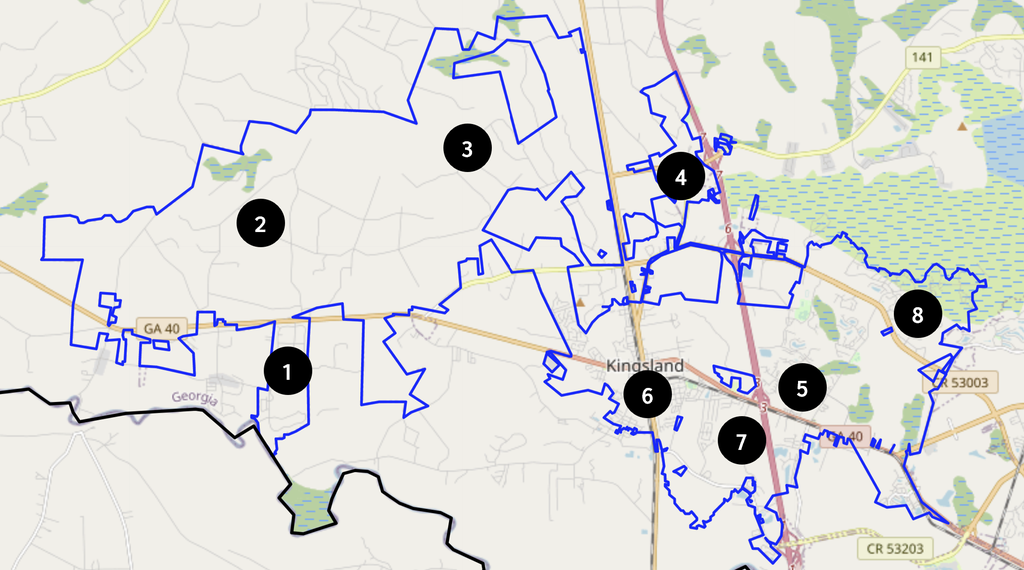

Survey Map Insert

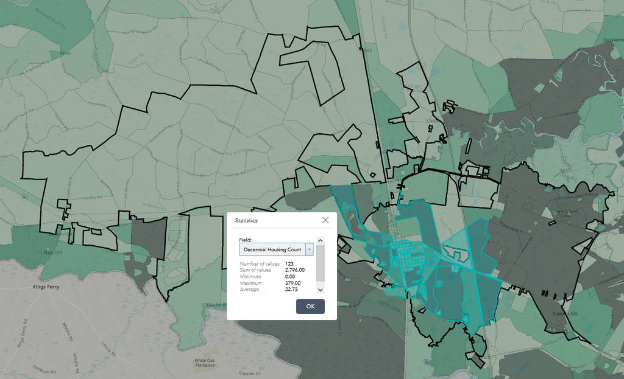

Census Tract in Proposed CDBG-DR-Infrastructure Project Area

## Step 4: Conducting the Survey

## Step 5: Determining the Results

## Step 6: Documenting Your Effort

# Low- and moderate-income worksheet

## Part A. Information Contained in Your Survey

1. Enter the estimated total number of families in the target area.  
   **2796**
2. Enter the total number of families interviewed.  
   **215**
3. Enter the total number of low- and moderate- income families interviewed.  
   **72**
4. Enter the total number of persons living in the low- and moderate-income families interviewed.  
   **232**
5. Enter the total number of non-low- and moderate-income families interviewed.  
   **143**
6. Enter the total number of persons living in the non-low- and moderate-income families.  
   **432**

## Part B. Calculations Based on Data Contained in Your Survey

7. Divide Line 4 by Line 3. (This is the average size of the low-mod family you interviewed)  
   **3.22**
8. Divide Line 6 by Line 5. (This is the average size of non-low-mod family you interviewed)  
   **3.02**
9. Divide Line 3 by Line 2. (This is the proportion of families interviewed that have low and moderate incomes)  
   **0.33**
10. Divide Line 5 by Line 2. (This is the proportion of families interviewed that do not have low and moderate incomes)  
    **0.67**
11. Multiply Line 1 by Line 9. (This is the estimate of the total number of low-mod families in your target area)  
    **936.33**
12. Multiply Line 1 by Line 10. (This is the estimate of the total number of non-low-mod families in your target area.)  
    **1860**
13. Multiply Line 7 by Line 11. (This is the estimate of the total number of low-mod persons in your target area.)  
    **3017**
14. Multiply Line 8 by Line 12. (This is the estimate of the total number non-low-mod persons in your target area.)  
    **5618**
15. Add Line 13 and Line 14. (This is the estimate of the total number of persons in your target area)  
    **8635**
16. Divide Line 13 by Line 15, and multiply the resulting decimal by 100. (This is the estimated percentage of persons in your target area who have low and moderate Incomes.)  
    **34.94**